# VIELLE TECHNOLOGIQUE PYPLOT

### Matplotlib

Matplotlib est une bibliothèque permettant de créer des visualisations statiques, animées et interactives en Python.

### pyplot

PYPLOT est de la bibliothèque de matplotlib qui nous permettra de faire des graphes.

#### importation de bibliotheque

Pyplot La plupart des utilitaires Matplotlib se trouvent sous le sous- pyplotmodule et sont généralement importés sous l' plt.

L’instruction plot() permet de tracer des courbes qui relient des points dont les abscisses et ordonnées sont fournies dans des tableaux il existe essentiellement deux façons d'utiliser Matplotlib :

Il existe essentiellement deux façons d'utiliser Matplotlib :

Créez explicitement des figures et des axes, et appelez des méthodes sur eux (le "style orienté objet (OO)").

Faites confiance à pyplot pour créer et gérer automatiquement les figures et les axes, et utilisez les fonctions pyplot pour le traçage.

Pour tracer des courbes, Python n’est pas suffisant et nous avons besoin des bibliothèques NumPy et matplotlib

L’instruction plot() permet de tracer des courbes qui relient des points dont les abscisses et ordonnées sont fournies dans des tableaux.

Il est possible fixer indépendamment les domaines des abscisses et des ordonnées en utilisant les fonctions xlim() et ylim().

On peut ajouter un titre grâce à l’instruction title().

legend() pou ajouter une legend

Des labels sur les axes peuvent être ajoutés avec les fonctions xlabel() et ylabel().

Pour faire afficher le label, il ne faut pas oublier de faire appel à l’instruction legend().

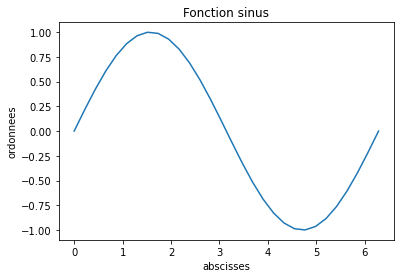

```python
## nous allons tracer la fonction sinus.
x = np.linspace(0, 2*np.pi, 30)
y = np.sin(x)
plt.plot(x, y)
plt.xlabel("abscisses")
plt.ylabel("ordonnees")
plt.title("Fonction sinus") # pour donner un titre
plt.show() #plt.show() # affiche la figure a l'ecran
```

## Affichage de plusieurs courbes

Pour afficher plusieurs courbes sur un même graphe, on peut procéder de la façon suivante :

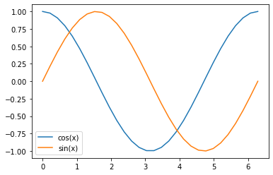

```python
x = np.linspace(0, 2*np.pi, 30)
y1 = np.cos(x)
y2 = np.sin(x)
plt.plot(x, y1, label="cos(x)")
plt.plot(x, y2, label="sin(x)")
plt.legend()

plt.show()
```

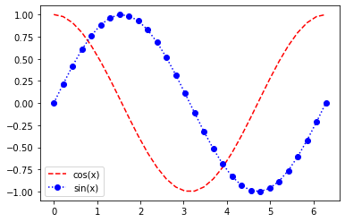

```python
#Il est possible de préciser la couleur, le style de ligne et de symbole (« marker ») en ajoutant une chaîne de caractères de la façon suivante :

x = np.linspace(0, 2*np.pi, 30)
y1 = np.cos(x)
y2 = np.sin(x)
plt.plot(x, y1, "r--", label="cos(x)")
plt.plot(x, y2, "b:o", label="sin(x)")
plt.legend()

plt.show()
```

# DEMO

```python
# importation de la bibliotheque matplotlib
import matplotlib.pyplot as plt
import numpy as np
import pandas as pd
```

```python
#impotation de mes données
df=pd.read_table("C:/Users/Admin/Documents/heart.txt")
df
```

|  | age | sexe | pression | cholester | sucre | electro | taux_max | angine | depression | pic | vaisseau | coeur |
| --- | --- | --- | --- | --- | --- | --- | --- | --- | --- | --- | --- | --- |
| 0 | 58 | masculin | 100 | 234 | A | A | 156 | non | 1 | 1 | B | presence |
| 1 | 41 | feminin | 130 | 204 | A | C | 172 | non | 14 | 1 | A | absence |
| 2 | 58 | masculin | 150 | 270 | A | C | 111 | oui | 8 | 1 | A | presence |
| 3 | 53 | masculin | 140 | 203 | B | C | 155 | oui | 31 | 3 | A | presence |
| 4 | 41 | masculin | 130 | 214 | A | C | 168 | non | 20 | 2 | A | absence |
| ... | ... | ... | ... | ... | ... | ... | ... | ... | ... | ... | ... | ... |
| 265 | 62 | feminin | 140 | 268 | A | C | 160 | non | 36 | 3 | C | presence |
| 266 | 62 | masculin | 130 | 231 | A | A | 146 | non | 18 | 2 | D | absence |
| 267 | 64 | masculin | 110 | 211 | A | C | 144 | oui | 18 | 2 | A | absence |
| 268 | 63 | feminin | 150 | 407 | A | C | 154 | non | 40 | 2 | D | presence |
| 269 | 35 | feminin | 138 | 183 | A | A | 182 | non | 14 | 1 | A | absence |

270 rows × 12 columns

```
array([[<AxesSubplot:title={'center':'age'}>]], dtype=object)
```

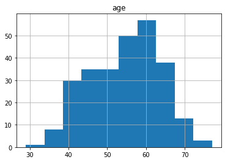

```python
#histogramme de l'âge
df.hist(column='age')
```

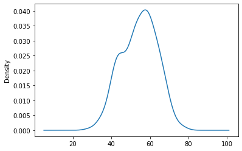

```python
#density plot
df['age'].plot.kde()
```

```
array([<AxesSubplot:title={'center':'feminin'}>,
       <AxesSubplot:title={'center':'masculin'}>], dtype=object)
```

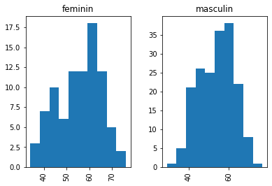

```python
#histogrammes de l'âge selon le sexe
df.hist(column='age',by='sexe')
```